# Code examples in R for Chapter 6

Daniel P. Palomar

03 March 2022

# Packages

The following packages are used in the examples:

```r
# basic finance
library(xts)                    # to manipulate time series of stock data
library(quantmod)               # to download stock data
library(PerformanceAnalytics)   # to compute performance measures
library(portfolioBacktest)      # to conduct backtests
library(pob)                    # book package with financial data

# plotting
library(ggplot2)                # for nice plots
library(magrittr)               # for pipeline operator %>%
library(reshape2)

# optimization
library(CVXR)
library(riskParityPortfolio)
```

# Preliminaries

We start with basic aspects such as data loading and plotting.

##### Loading market data

Loading market data could be conveniently done with the package `quantmod` from Yahoo!Finance or any other source:

```r
# download data from Yahoo!Finance
getSymbols(c("AMD", "MGM", "AAPL", "AMZN", "TSCO"), from = "2019-10-01", to = "2021-12-31")

# extract the adjusted close prices of AAPL
Ad(APPL)
```

However, for convenience we will use stock data and cryptocurrency data from the official portfolio optimization book package `pob`:

```r
# crypto data
data(cryptos_2017to2021)
names(cryptos_2017to2021)
R>> [1] "daily"  "hourly"
head(cryptos_2017to2021$hourly[, 1:5])
R>>                          BTC      ETH       ADA       DOT       XRP
R>> 2021-01-07 09:00:00 37485.61 1204.525 0.3309979 10.005659 0.3051329
R>> 2021-01-07 10:00:00 37040.38 1183.403 0.3085464  9.677910 0.3237329
R>> 2021-01-07 11:00:00 37806.57 1201.001 0.3119042  9.823281 0.3579904
R>> 2021-01-07 12:00:00 37936.25 1227.162 0.3179058  9.966991 0.3364566
R>> 2021-01-07 13:00:00 38154.69 1218.127 0.3185917  9.882065 0.3285119
R>> 2021-01-07 14:00:00 38441.49 1223.862 0.3156046  9.785281 0.3412451

# stock S&P500 market data
data(SP500_2015to2020)
names(SP500_2015to2020)
R>> [1] "stocks" "index"
head(SP500_2015to2020$stocks[, 1:5])
R>>                  A     AAL     AAP   AAPL    ABBV
R>> 2015-01-05 37.7523 51.0467 154.217 24.239 50.8722
R>> 2015-01-06 37.1642 50.2556 154.108 24.241 50.6204
R>> 2015-01-07 37.6574 50.2272 157.420 24.581 52.6663
R>> 2015-01-08 38.7862 50.8430 158.800 25.526 53.2171
R>> 2015-01-09 38.5016 49.2891 157.991 25.553 51.7614
R>> 2015-01-12 38.0463 46.9772 156.641 24.923 51.7457
```

##### Plotting data

Plotting data could be conveniently done with the packages `xts` and `PerformanceAnalytics`:

```r
stock_prices <- SP500_2015to2020$stocks["2019-10::", "AAPL"]

# basic xts plot
plot(stock_prices)

# using PerformanceAnalytics
rets <- CalculateReturns(stock_prices)
chart.CumReturns(rets)
chart.Drawdown(rets)
```

However, we prefer to use the package `ggplot2` for more beautiful plots (albeit at the expense of a few extra lines of code):

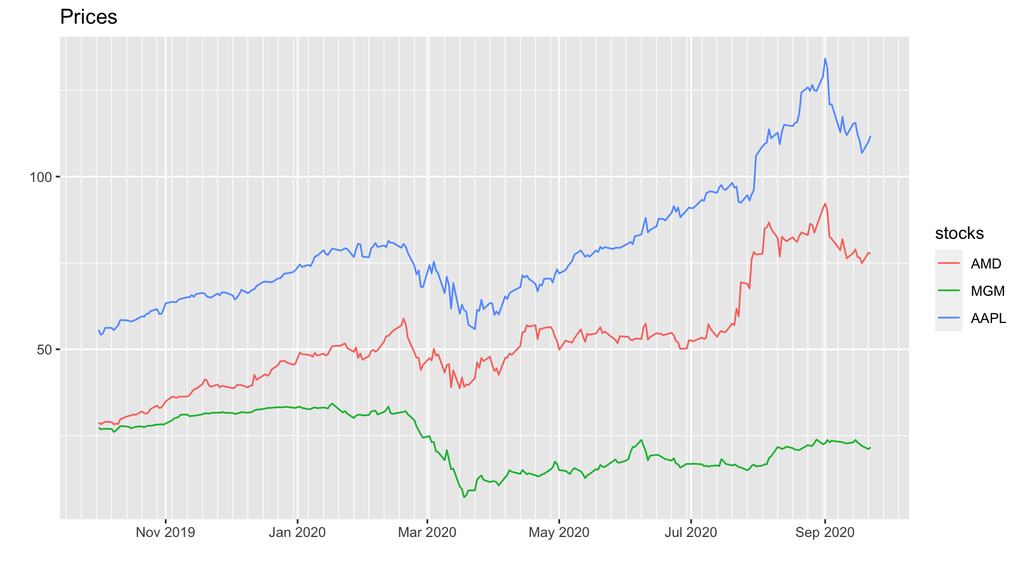

```r
stock_prices <- SP500_2015to2020$stocks["2019-10::", c("AMD", "MGM", "AAPL")]
rets <- stock_prices/lag(stock_prices) - 1

ggplot(fortify(stock_prices, melt = TRUE), aes(x = Index, y = Value, color = Series)) +
  geom_line() +
  scale_x_date(date_breaks = "2 months", date_labels = "%b %Y", date_minor_breaks = "1 week") +
  labs(title = "Prices", x = "", y = "", color = "stocks")
```

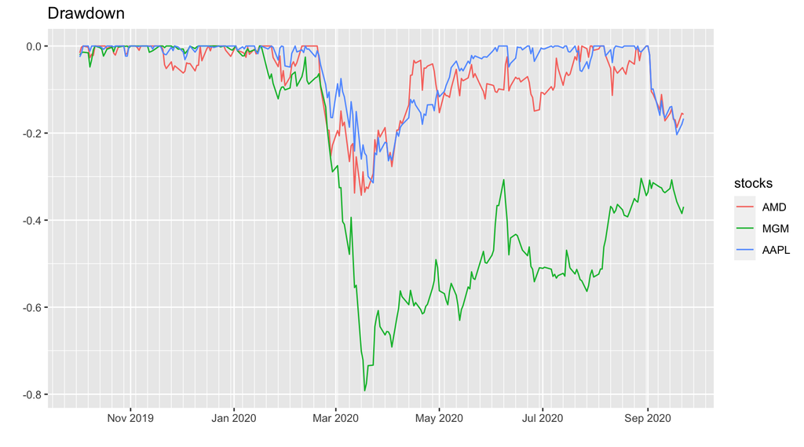

```r
ggplot(fortify(Drawdowns(rets), melt = TRUE), aes(x = Index, y = Value, color = Series)) +
  geom_line() +
  scale_x_date(date_breaks = "2 months", date_labels = "%b %Y", date_minor_breaks = "1 week") +
  labs(title = "Drawdown", x = "", y = "", color = "stocks")
```

# Backtesting

We now consider how to perform backtests and explore rebalancing aspects.

##### Naive backtesting

For illustrative purposes we now backtest the $1/N$ portfolio:

```r
stock_prices <- SP500_2015to2020$stocks["2019-10::", c("AMD", "MGM", "AAPL", "AMZN", "TSCO")]
N <- ncol(stock_prices)
T <- nrow(stock_prices)

# linear returns
X <- stock_prices/lag(stock_prices) - 1

# portfolio
w <- rep(1/N, N)

# naive backtest (assumed daily rebalancing and no transaction cost)
portf_ret <- xts(X %*% w, index(X))
head(na.omit(portf_ret))
R>>                    [,1]
R>> 2019-10-02 -0.013131245
R>> 2019-10-03  0.012373766
R>> 2019-10-04  0.009848104
R>> 2019-10-07 -0.003871650
R>> 2019-10-08 -0.016876593
R>> 2019-10-09  0.011320010
```

However, multiplying the matrix of linear returns of the assets `X` by the portfolio `w` implicitly assumes that we are rebalancing at every period (and also ignoring the transaction costs). To perform more realistic backtests we can use the package `portfolioBactest` where one can specify how often the portfolio is reoptimized, rebalanced, and the lookback windows to be used in a rolling-window basis (as well as transaction costs). Let’s start by reproducing the previous naive backtest assuming daily rebalancing:

```r
# define our portfolio
EWP <- function(data, ...) {
  N <- ncol(data$prices)
  return(rep(1/N, N))
}

# perform backtest
bt <- portfolioBacktest(portfolio_funs = list("1/N" = EWP),
                        dataset_list = list(list("prices" = stock_prices)), price_name = "prices",
                        lookback = 1, optimize_every = 1, rebalance_every = 1)
R>> Backtesting 1 portfolios over 1 datasets (periodicity = daily data)...

head(bt$`1/N`$data1$return)
R>>                  return
R>> 2019-10-02 -0.013131245
R>> 2019-10-03  0.012373766
R>> 2019-10-04  0.009848104
R>> 2019-10-07 -0.003871650
R>> 2019-10-08 -0.016876593
R>> 2019-10-09  0.011320010
```

##### Rebalancing in backtesting

Now we can perform a more realistic backtest rebalancing, say, every week (i.e., 5 days), including transaction costs:

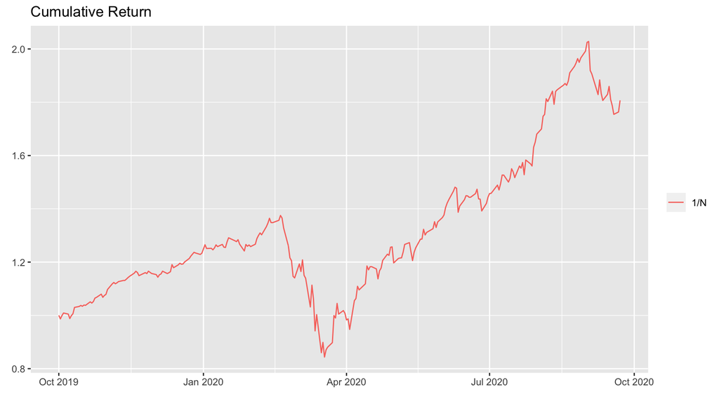

```r
bt <- portfolioBacktest(portfolio_funs = list("1/N" = EWP),
                        dataset_list = list(list("prices" = stock_prices)), price_name = "prices",
                        lookback = 1, optimize_every = 5, rebalance_every = 5,
                        cost = list(buy = 30e-4, sell = 30e-4))
R>> Backtesting 1 portfolios over 1 datasets (periodicity = daily data)...
head(bt$`1/N`$data1$wealth)
R>>                  NAV
R>> 2019-10-01 1.0000000
R>> 2019-10-02 0.9868688
R>> 2019-10-03 0.9991699
R>> 2019-10-04 1.0088971
R>> 2019-10-07 1.0049400
R>> 2019-10-08 0.9881182
backtestChartCumReturn(bt)
```

Let’s observe the evolution of the $1/N$ portfolio over time for a universe of 5 stocks, showing the effect of rebalancing (indicated with black vertical lines):

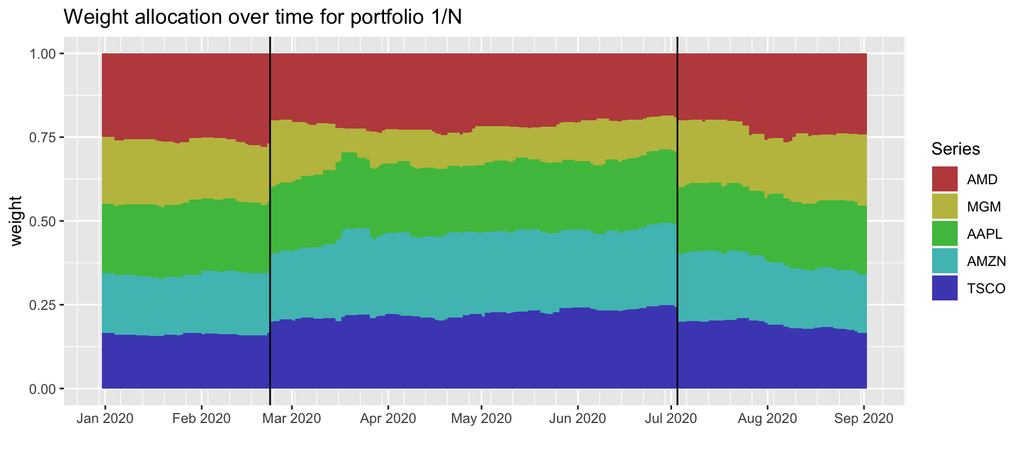

```r
stock_prices <- SP500_2015to2020$stocks["2019-10::", c("AMD", "MGM", "AAPL", "AMZN", "TSCO")]

bt <- portfolioBacktest(portfolio_funs = list("1/N" = EWP),
                        dataset_list = list(list("prices" = stock_prices)), price_name = "prices",
                        lookback = 10, optimize_every = 90, rebalance_every = 90)
R>> Backtesting 1 portfolios over 1 datasets (periodicity = daily data)...

bt$`1/N`$data1$w_bop["2020-01::2020-08", ] %>%
  fortify(melt = TRUE) %>%
  ggplot(aes(x = Index, y = Value, fill = Series)) +
  geom_bar(stat = "identity", width = 4.0) +
  scale_fill_manual(values = rainbow6equal) +
  scale_x_date(date_breaks = "1 month", date_labels = "%b %Y", date_minor_breaks = "1 week") +
  labs(title = "Weight allocation over time for portfolio 1/N", x = "", y = "weight", color = "stocks") +
  geom_vline(xintercept = as.Date("2020-02-23"), color = "black") +
  geom_vline(xintercept = as.Date("2020-07-03"), color = "black")
```

# Heuristic portfolios

We now compare the following heuristic portfolios:

- $1/N"$ portfolio;
- GMRP;
- Quintile portfolio (sorting stocks by $\bm{\mu}$);
- Quintile portfolio (sorting stocks by $\bm{\mu}/\bm{\sigma}$); and
- Quintile portfolio (sorting stocks by $\bm{\mu}/\bm{\sigma}^2$).

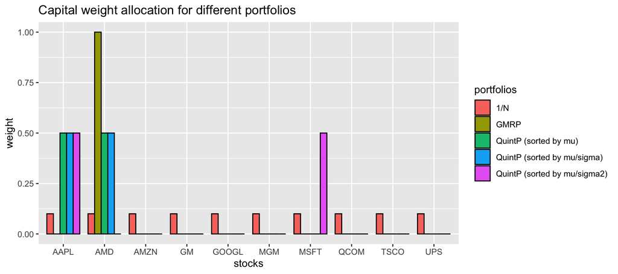

```r
data(SP500_2015to2020)
stock_prices <- SP500_2015to2020$stocks["2019::", c("AAPL", "AMZN", "AMD", "GM", "GOOGL", "MGM", "MSFT", "QCOM", "TSCO", "UPS")]
T <- nrow(stock_prices)
T_trn <- round(0.70*T)

#
# Define portfolios
#
QuintP_mu <- function(dataset, ...) {
  N <- ncol(dataset$prices)
  X <- diff(log(dataset$prices))[-1]
  mu <- colMeans(X)
  idx <- order(mu, decreasing = TRUE)
  w <- rep(0, N)
  w[idx[1:round(N/5)]] <- 1/round(N/5)
  return(w)
}

QuintP_mu_over_sigma <- function(dataset, ...) {
  N <- ncol(dataset$prices)
  X <- diff(log(dataset$prices))[-1]
  mu <- colMeans(X)
  Sigma <- cov(X)
  idx <- order(mu/sqrt(diag(Sigma)), decreasing = TRUE)
  w <- rep(0, N)
  w[idx[1:round(N/5)]] <- 1/round(N/5)
  return(w)
}

QuintP_mu_over_sigma2 <- function(dataset, ...) {
  N <- ncol(dataset$prices)
  X <- diff(log(dataset$prices))[-1]
  mu <- colMeans(X)
  Sigma <- cov(X)
  idx <- order(mu/diag(Sigma), decreasing = TRUE)
  w <- rep(0, N)
  w[idx[1:round(N/5)]] <- 1/round(N/5)
  return(w)
}

GMRP <- function(dataset, ...) {
  N <- ncol(dataset$prices)
  X <- diff(log(dataset$prices))[-1]
  mu <- colMeans(X)
  i_max <- which.max(mu)
  w <- rep(0, N)
  w[i_max] <- 1
  return(w)
}

# single backtest
bt <- portfolioBacktest(
  portfolio_funs = list("1/N"                          = EWP,
                        "GMRP"                         = GMRP,
                        "QuintP (sorted by mu)"        = QuintP_mu,
                        "QuintP (sorted by mu/sigma)"  = QuintP_mu_over_sigma,
                        "QuintP (sorted by mu/sigma2)" = QuintP_mu_over_sigma2),
  dataset_list = list(list("prices" = stock_prices)), price_name = "prices",
  lookback = T_trn, optimize_every = 30, rebalance_every = 1)
R>> Backtesting 5 portfolios over 1 datasets (periodicity = daily data)...

# barplot
data.frame(
  "stocks" = names(stock_prices),
  "1/N"    = as.numeric(bt$`1/N`$data1$w_optimized[1, ]),
  "GMRP"   = as.numeric(bt$`GMRP`$data1$w_optimized[1, ]),
  "QuintP (sorted by mu)" = as.numeric(bt$`QuintP (sorted by mu)`$data1$w_optimized[1, ]),
  "QuintP (sorted by mu/sigma)" = as.numeric(bt$`QuintP (sorted by mu/sigma)`$data1$w_optimized[1, ]),
  "QuintP (sorted by mu/sigma2)" = as.numeric(bt$`QuintP (sorted by mu/sigma2)`$data1$w_optimized[1, ]),
  check.names = FALSE
) %>% melt(., id.vars = "stocks") %>%
  ggplot(aes(x = stocks, y = value, fill = variable)) +
  geom_bar(stat = "identity", position = "dodge", color = "black", width = 0.8) +
  labs(title = "Capital weight allocation for different portfolios", y = "weight", fill = "portfolios")
```

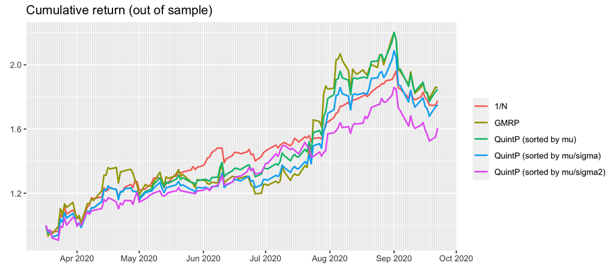

```r
backtestChartCumReturn(bt) +
  geom_line(size = 0.8) +
  scale_x_date(date_breaks = "1 month", date_labels = "%b %Y", date_minor_breaks = "1 day") +
  ggtitle("Cumulative return (out of sample)")
```

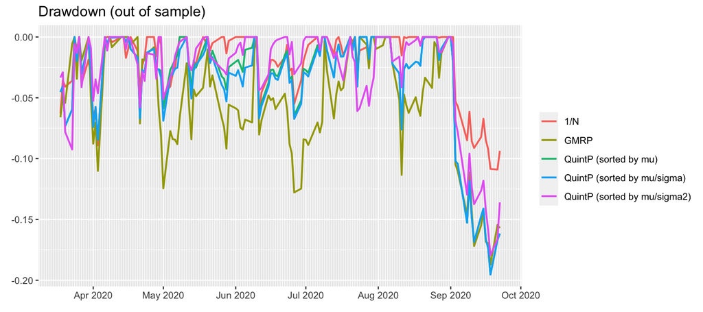

```r
backtestChartDrawdown(bt) +
  geom_line(size = 0.8) +
  scale_x_date(date_breaks = "1 month", date_labels = "%b %Y", date_minor_breaks = "1 day") +
  ggtitle("Drawdown (out of sample)")
```

```r
summary_bt <- backtestSummary(bt)
options(DT.options = list(dom = "t"))  # only show bare table (no search box)
summaryTable(summary_bt, type = "DT",
             measures = c("Sharpe ratio", "annual return", "annual volatility", "max drawdown"))
```

|  | Sharpe ratio | annual return | annual volatility | max drawdown |
| --- | --- | --- | --- | --- |
| 1/N | 3.2283 | 1.1739 | 0.3636 | 0.109 |
| GMRP | 2.1938 | 1.3838 | 0.6308 | 0.1871 |
| QuintP (sorted by mu) | 2.7301 | 1.2919 | 0.4732 | 0.1953 |
| QuintP (sorted by mu/sigma) | 2.5053 | 1.1899 | 0.4749 | 0.1953 |
| QuintP (sorted by mu/sigma2) | 2.4813 | 0.9923 | 0.3999 | 0.1795 |

# Risk-based portfolios

We now compare the following risk-based portfolios:

- GMVP;
- IVP;
- RPP;
- MDP; and
- MDCP.

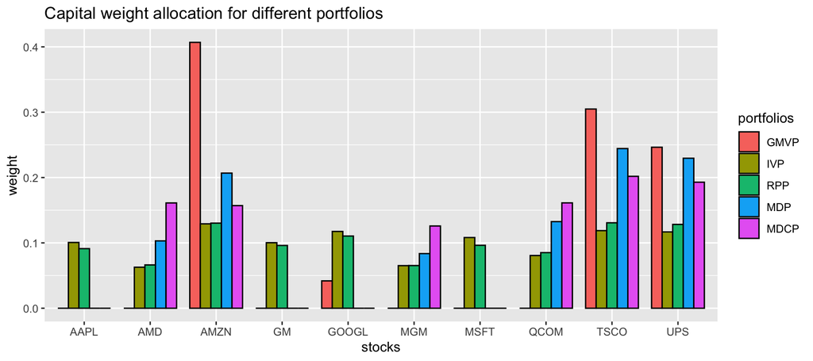

```r
data(SP500_2015to2020)
stock_prices <- SP500_2015to2020$stocks["2019::", c("AAPL", "AMZN", "AMD", "GM", "GOOGL", "MGM", "MSFT", "QCOM", "TSCO", "UPS")]
T <- nrow(stock_prices)
T_trn <- round(0.70*T)

#
# Define portfolios
#
design_GMVP <- function(Sigma) {
  w <- Variable(nrow(Sigma))
  prob <- Problem(Minimize(quad_form(w, Sigma)),
                  constraints = list(w >= 0, sum(w) == 1))
  result <- solve(prob)
  w <- as.vector(result$getValue(w))
  return(w)
}

GMVP <- function(dataset, ...) {
  N <- ncol(dataset$prices)
  X <- diff(log(dataset$prices))[-1]
  Sigma <- cov(X)
  w <- design_GMVP(Sigma)
  return(w)
}

design_IVP <- function(Sigma) {
  sigma <- sqrt(diag(Sigma))
  w <- 1/sigma
  w <- w/sum(w)
  return(w)
}

IVP <- function(dataset, ...) {
  N <- ncol(dataset$prices)
  X <- diff(log(dataset$prices))[-1]
  Sigma <- cov(X)
  w <- design_IVP(Sigma)
  return(w)
}


RPP <- function(dataset, ...) {
  N <- ncol(dataset$prices)
  X <- diff(log(dataset$prices))[-1]
  Sigma <- cov(X)
  w <- riskParityPortfolio(Sigma)$w
  return(w)
}

design_MSRP <- function(mu, Sigma) {
  w_ <- Variable(nrow(Sigma))
  prob <- Problem(Minimize(quad_form(w_, Sigma)),
                  constraints = list(w_ >= 0, t(mu) %*% w_ == 1))
  result <- solve(prob)
  w <- as.vector(result$getValue(w_)/sum(result$getValue(w_)))
  names(w) <- colnames(Sigma)
  return(w)
}

MDP <- function(dataset, ...) {
  N <- ncol(dataset$prices)
  X <- diff(log(dataset$prices))[-1]
  Sigma <- cov(X)
  w <- design_MSRP(mu = sqrt(diag(Sigma)), Sigma)
  return(w)
}

design_MDCP <- function(Sigma) {
  C <- diag(1/sqrt(diag(Sigma))) %*% Sigma %*% diag(1/sqrt(diag(Sigma)))
  colnames(C) <- colnames(Sigma)
  return(design_GMVP(Sigma = C))
}

MDCP <- function(dataset, ...) {
  N <- ncol(dataset$prices)
  X <- diff(log(dataset$prices))[-1]
  Sigma <- cov(X)
  w <- design_MDCP(Sigma)
  return(w)
}


# single backtest
bt <- portfolioBacktest(portfolio_funs = list("GMVP"  = GMVP,
                                              "IVP"   = IVP,
                                              "RPP"   = RPP,
                                              "MDP"   = MDP,
                                              "MDCP"  = MDCP),
                        dataset_list = list(list("prices" = stock_prices)), price_name = "prices",
                        lookback = T_trn, optimize_every = 30, rebalance_every = 1)
R>> Backtesting 5 portfolios over 1 datasets (periodicity = daily data)...

# barplot
data.frame(
  "stocks" = names(stock_prices),
  "GMVP"   = as.numeric(bt$`GMVP`$data1$w_optimized[1, ]),
  "IVP"    = as.numeric(bt$`IVP`$data1$w_optimized[1, ]),
  "RPP"    = as.numeric(bt$`RPP`$data1$w_optimized[1, ]),
  "MDP"    = as.numeric(bt$`MDP`$data1$w_optimized[1, ]),
  "MDCP"   = as.numeric(bt$`MDCP`$data1$w_optimized[1, ]),
  check.names = FALSE
) %>% melt(., id.vars = "stocks") %>%
  ggplot(aes(x = stocks, y = value, fill = variable)) +
  geom_bar(stat = "identity", position = "dodge", color = "black", width = 0.8) +
  labs(title = "Capital weight allocation for different portfolios", y = "weight", fill = "portfolios")
```

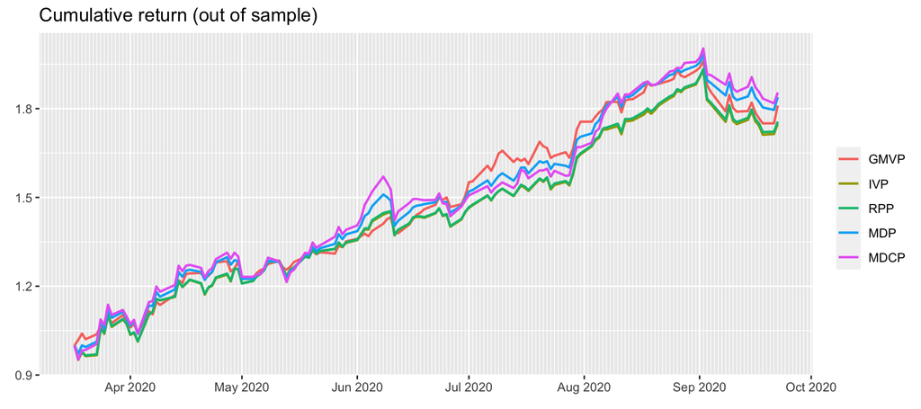

```r
backtestChartCumReturn(bt) +
  geom_line(size = 0.8) +
  scale_x_date(date_breaks = "1 month", date_labels = "%b %Y", date_minor_breaks = "1 day") +
  ggtitle("Cumulative return (out of sample)")
```

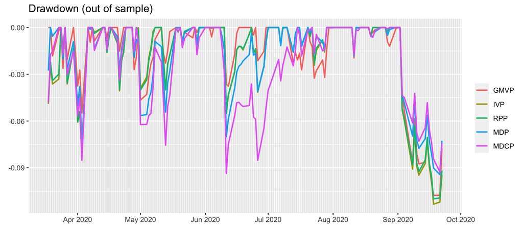

```r
backtestChartDrawdown(bt) +
  geom_line(size = 0.8) +
  scale_x_date(date_breaks = "1 month", date_labels = "%b %Y", date_minor_breaks = "1 day") +
  ggtitle("Drawdown (out of sample)")
```

```r
summary_bt <- backtestSummary(bt)
summaryTable(summary_bt, type = "DT",
             measures = c("Sharpe ratio", "annual return", "annual volatility", "max drawdown"))
```

|  | Sharpe ratio | annual return | annual volatility | max drawdown |
| --- | --- | --- | --- | --- |
| GMVP | 4.0524 | 1.1861 | 0.2927 | 0.1077 |
| IVP | 3.3523 | 1.1328 | 0.3379 | 0.1133 |
| RPP | 3.4015 | 1.1406 | 0.3353 | 0.1099 |
| MDP | 3.7856 | 1.2259 | 0.3238 | 0.0944 |
| MDCP | 3.4222 | 1.2572 | 0.3674 | 0.0936 |